# Visualization of CNS signature fitting with `deconstructSigs`

SJ Spielman

2022

#### Files and paths

```r
`%>%` <- dplyr::`%>%`
proj_root_path  <- file.path( rprojroot::find_root(rprojroot::has_dir(".git")) )
analysis_path   <- file.path(proj_root_path, "analyses", "mutational-signatures")
plot_path       <- file.path(analysis_path, "plots", "cns")
if (!dir.exists(plot_path)) {
  dir.create(plot_path, recursive = TRUE)
}

# Input files
fitted_file    <- file.path(analysis_path, "results", "fitted_exposures_signal-cns_deconstructSigs.rds")
meta_file      <- file.path(proj_root_path, "data", "pbta-histologies.tsv")


histology_palette_file   <- file.path(proj_root_path, "figures", "palettes", "broad_histology_cancer_group_palette.tsv")
binary_palette_file <- file.path(proj_root_path, "figures", "palettes", "binary_color_palette.tsv")
tumor_palette_file <-  file.path(proj_root_path, "figures", "palettes", "tumor_descriptor_palette.tsv")

# Output plots
exposures_sample_barplot_file <- file.path(analysis_path, "plots", "cns", "exposures_per_sample_barplot.pdf")
exposures_sina_IQR_file <- file.path(analysis_path, "plots", "cns", "exposures_sina_IQR.pdf")
exposures_presence_barplot_file <- file.path(analysis_path, "plots", "cns", "exposures_presence_barplot.pdf")
signature1_tumor_cancergroups_file <- file.path(analysis_path, "plots", "cns", "signature1_tumor-descriptor_cancer-groups.pdf")
signature1_tumor_molecularsubtypes_file <- file.path(analysis_path, "plots", "cns", "signature1_tumor-descriptor_molecular-subtypes.pdf")

# Output result file which contains merged/prepped data for visualization, also used in the `08` notebooks
results_df_file <- file.path("results", "deconstructsigs_exposures_merged.tsv")


# The real signature names: https://signal.mutationalsignatures.com/explore/studyTissueType/1-6
signature_names_df <- tibble::tibble(
  signature = factor(
    c("11", "1", "N6", "8", "MMR2", "18", "19", "3", "Other"),
    levels = c("1", "3", "8", "11", "18", "19", "N6", "MMR2", "Other")),
  cns_names   = c(paste0("CNS_",LETTERS[1:8]), "Other")
)
```

First, we read in data and prepare exposures.

```r
# Read in metadata and palette files
meta <- readr::read_tsv(meta_file, guess_max = 10000)
palette_df <- readr::read_tsv(histology_palette_file)
binary_df <- readr::read_tsv(binary_palette_file)
binary_colors <- binary_df$hex_codes[binary_df$color_names != "na_color"]
tumor_df <- readr::read_tsv(tumor_palette_file)
# Read in exposures from CNS signature fitting and tibble it up, including the "unknown" weight
raw_exposures <- readr::read_rds(fitted_file)
decon_weights <- lapply(raw_exposures, "[[", "weights")
exposures_wide <- do.call(rbind, decon_weights) %>%
  tibble::rownames_to_column("Kids_First_Biospecimen_ID") %>%
  tibble::as_tibble()

unknown_weights <- lapply(raw_exposures, "[[", "unknown")
unknown_weights_array <- do.call(rbind, unknown_weights)
exposures <- exposures_wide %>%
  # use "Other" for unknown
  dplyr::mutate(Other = unknown_weights_array[,1]) %>%
  # key is column name in signature_names_df
  tidyr::gather(-Kids_First_Biospecimen_ID, key = "cns_names", value = "exposure")
```

Now we prepare the data for visualization, including merging data frames and further setting up palettes. Note that we are plotting here only the cancer groups used in the [`interaction-plots` module](https://github.com/AlexsLemonade/OpenPBTA-analysis/blob/master/analyses/interaction-plots/scripts/03-plot_interactions.R). Also see [this discussion](https://github.com/AlexsLemonade/OpenPBTA-analysis/issues/1474).

```r
# Cancer groups we are showing in figure 4
cancer_groups_to_plot <- c(
  "Diffuse midline glioma",
  "Other high-grade glioma",
  "Pilocytic astrocytoma",
  "Ganglioglioma",
  "Pleomorphic xanthoastrocytoma",
  "Other low-grade glioma",
  "Medulloblastoma",
  "Atypical Teratoid Rhabdoid Tumor",
  "Other embryonal tumor",
  "Ependymoma",
  "Craniopharyngioma",
  "Meningioma"
)

# Join input dataframes together
results_df <- exposures %>%
  # Merge with metadata
  dplyr::inner_join(
    meta %>%
      dplyr::select(Kids_First_Biospecimen_ID, broad_histology, cancer_group, tumor_descriptor)
  ) %>%
  # Drop unknown cancer groups - needed for cleaning duplicates.
  tidyr::drop_na(cancer_group) %>%
  # Grab the cancer group DISPLAY specifically (needed for joining later)
  dplyr::inner_join(
      # Must retain broad_histology in order to properly join the Oligodendroglioma samples
      #  which can be either high- or low-grade glioma cancer groups
      dplyr::select(palette_df, broad_histology, cancer_group, cancer_group_display)
  ) %>%
  # no longer need cancer_group
  dplyr::select(-cancer_group) %>%
  # Retain only cancer groups for these visualizations
  dplyr::filter(cancer_group_display %in% cancer_groups_to_plot) %>%
  # Merge with correct signal names (already factored and ordered)
  dplyr::inner_join(signature_names_df)  %>%
  dplyr::select(-cns_names) # remove signature column
# We need to create a new scheme for labeling that shows wrapped cancer groups with `(n=X)`
results_df <- results_df %>%
  dplyr::count(cancer_group_display, signature) %>%
  dplyr::select(-signature) %>%
  dplyr::distinct() %>%
  dplyr::inner_join(
      dplyr::select(palette_df, cancer_group_display, cancer_group_hex)
  ) %>%
  dplyr::select(cancer_group_display, n, cancer_group_hex) %>%
  dplyr::distinct() %>%
  # Create wrapped with (n=X) factor column for cancer groups
  dplyr::mutate(cancer_group_display_n = stringr::str_wrap(glue::glue("{cancer_group_display} (N={n})"), 25),
                cancer_group_display_n = forcats::fct_reorder(cancer_group_display_n, n, .desc=T)) %>%
  dplyr::inner_join(results_df)
# We also write `results_df` to a file since it will be used by the `08` notebook.
readr::write_tsv(
  # remove column with \n first
  dplyr::select(results_df, -cancer_group_display_n),
  results_df_file
)
```

### Sina/IQR of exposures across cancer groups

*All* samples are included in these sina plots, which show the distribution of exposures for each signature across samples in each cancer group. Notably, the “rug” of 0’s in each distribution represents samples which are unexposed to the given signature.

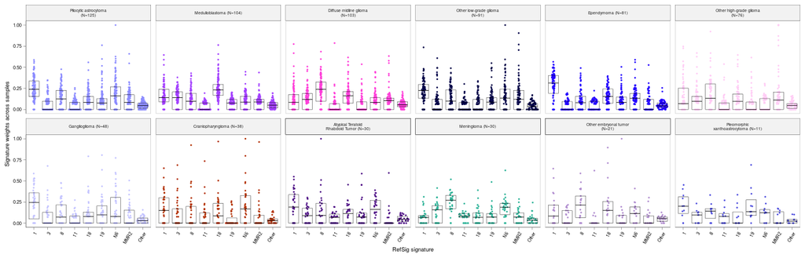

```r
# Set seed for sina reproducibility
set.seed(2022)

exposures_sina_boxplot <- results_df %>%
  ggplot2::ggplot() +
  ggplot2::aes(x = signature,
               y = exposure,
               color = cancer_group_hex) +
  ggforce::geom_sina(size = 0.35) +
  ggplot2::geom_boxplot(outlier.size = 0,
                        size = 0.15,
                        color = "black",
                        alpha = 0,
                        # remove whiskers
                        coef = 0) +
  ggplot2::facet_wrap(~cancer_group_display_n, nrow = 2) +
  ggplot2::scale_color_identity() +
  # commenting out because 2 points are somehow removed..
  #ggplot2::scale_y_continuous(limits = c(0, 1.2),
  #                            breaks = c(0, 0.25, 0.5, 0.75, 1.0)) +
  ggplot2::labs(
    x = "RefSig signature",
    y = "Signature weights across samples"
  ) +
  ggpubr::theme_pubr() +
  cowplot::panel_border() +
  ggplot2::theme(
    axis.text.x = ggplot2::element_text(size = 5.5, angle = 60, hjust = 1),
    axis.text.y = ggplot2::element_text(size = 5.5),
    axis.title = ggplot2::element_text(size = 7),
    strip.text = ggplot2::element_text(size = 5),
    strip.background = ggplot2::element_rect(size = 0.2),
    axis.line = ggplot2::element_line(size = 0.15),
    axis.ticks = ggplot2::element_line(size = 0.15),
    legend.position = "none"
  )
exposures_sina_boxplot
```

```r
# Sizing is based on full figure compilation:
ggplot2::ggsave(exposures_sina_IQR_file, exposures_sina_boxplot, width = 6, height = 2.25,
                useDingbats = FALSE)
```

We do *not* include “Other” in this plot.

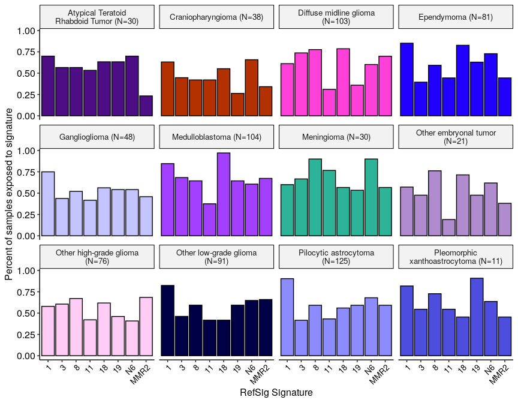

```r
exposures_proportions <- results_df %>%
  # remove "other" - not useful to know if samples are unexposed to signatures that aren't even present.
  dplyr::filter(signature != "Other") %>%
  dplyr::group_by(cancer_group_display_n, cancer_group_hex, signature) %>%
  dplyr::summarize(percent_exposed = sum(exposure > 0)/dplyr::n()) %>%
  dplyr::ungroup() %>%
  # wrap strip labels
  dplyr::mutate(cancer_group_display_n = stringr::str_wrap(cancer_group_display_n, 25)) %>%
  ggplot2::ggplot() +
  ggplot2::aes(x = signature, y = percent_exposed, fill = cancer_group_hex) +
  ggplot2::geom_col(color = "black") +
  ggplot2::facet_wrap(~cancer_group_display_n, nrow = 3) +
  ggplot2::scale_fill_identity() +
  ggplot2::labs(x = "RefSig Signature",
                y = "Percent of samples exposed to signature") +
  ggpubr::theme_pubr() +
  ggplot2::theme(axis.text.x = ggplot2::element_text(size = 10, angle = 45, hjust=1),
                 strip.text = ggplot2::element_text(size = 10))

exposures_proportions
```

```r
ggplot2::ggsave(exposures_presence_barplot_file, exposures_proportions, width = 9, height = 7)
```

### Barplot of sample exposures faceted across cancer groups

This plot shows the signature exposures for each sample. Each bar represents one sample, with fills representing the different signatures. We order plots by sample 1, and we include the unknown proportion so everything has the same height. In this case, “Other” specifically means mutations that were not assigned to the specific 8 CNS signatures examined, but are associated (if at all) with a different signature.

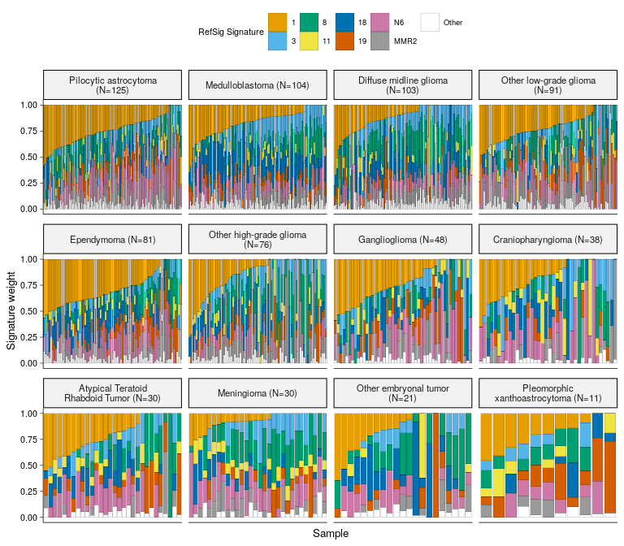

```r
# Make a column for exposure of interest to order samples by
samples_in_order <- results_df %>%
  dplyr::filter(signature == 1) %>%
  dplyr::select(exposure, Kids_First_Biospecimen_ID) %>%
  dplyr::arrange(-exposure) %>%
  dplyr::pull(Kids_First_Biospecimen_ID)

sample_exposures_barplot <- results_df %>%
  dplyr::mutate(Kids_First_Biospecimen_ID = factor(Kids_First_Biospecimen_ID, levels = samples_in_order)) %>%
  ggplot2::ggplot() +
  ggplot2::aes(x = Kids_First_Biospecimen_ID,
               y = exposure,
               fill = signature) +
  ggplot2::geom_col(color = "black", size = 0.05) +
  ggplot2::labs(x = "Sample", y = "Signature weight", fill = "RefSig Signature") +
  # Only 1:8 palette. The "Other" gets filled as white by including `color="black"` in the geom
  # There will be a warning about palette size and the warning is OK because ^^
  colorblindr::scale_fill_OkabeIto() +
  ggplot2::facet_wrap(~cancer_group_display_n, scales = "free_x", nrow = 3) +
  ggpubr::theme_pubr() +
  ggplot2::theme(
    axis.text.x  = ggplot2::element_blank(),
    axis.ticks.x = ggplot2::element_blank(),
    axis.title   = ggplot2::element_text(size = 10),
    axis.text.y   = ggplot2::element_text(size = 8),
    strip.text   = ggplot2::element_text(size = 8.5),
    axis.line = ggplot2::element_line(size = ggplot2::rel(0.5)),
    axis.ticks.y = ggplot2::element_line(size = ggplot2::rel(0.5)),
    legend.text = ggplot2::element_text(size = 7),
    legend.title = ggplot2::element_text(size = 8)
  )

sample_exposures_barplot
```

```r
ggplot2::ggsave(exposures_sample_barplot_file, sample_exposures_barplot, width = 8, height = 6.5)
```

### Explore: Signature 1 presence

Is there a relationship between the presence of signature 1 in a given sample, and either i) its molecular subtype, or ii) its tumor descriptor? Because signature 1 is a “normal” signature, we might expect that samples without signature 1 are more progressive/relapse and/or are associated with a specific subtype. For background discussion, see [here](https://github.com/AlexsLemonade/OpenPBTA-analysis/pull/1227).

We see somewhat of a relationship here, but the data sets are highly imbalanced across categories (include 0 and other very low counts), so the statistics are not extremely reliable.

```r
# Grab signature1 exposures.
sig1_exposures <- results_df %>%
  # Since exposures sum to 1 **including unknown**, we just need sig 1's exposure
  dplyr::filter(signature == 1) %>%
  dplyr::select(Kids_First_Biospecimen_ID,
                sig1_proportion = exposure,
                cancer_group_display_n) %>%
  # create indicator column of absence/presence
  dplyr::mutate(sig1_present = ifelse(sig1_proportion == 0, "Absent", "Present"),
                # Present should be first level
                sig1_present = forcats::fct_relevel(sig1_present, "Present")) %>%
  # merge in tumor descriptor and subtype information
  dplyr::inner_join(
    dplyr::select(meta, Kids_First_Biospecimen_ID, tumor_descriptor, molecular_subtype)
  )
```

Now, we can make contingency tables and compare signature 1 absence/presence with i) subtypes and ii) descriptors. We run some $\chi^2$-squared tests, **but** there are many low counts in these tables (and some 0!) *so we need to take these tests with a very very big boulder of salt.*

```r
# Subtypes:
table(sig1_exposures$molecular_subtype, sig1_exposures$sig1_present)
```

```
                                           Present Absent
  CNS Embryonal, NOS                             6      4
  CNS NB-FOXR2                                   2      0
  CRANIO, ADAM                                  22      5
  CRANIO, To be classified                       2      9
  DMG, H3 K28                                   25      9
  DMG, H3 K28, TP53 activated                   11      6
  DMG, H3 K28, TP53 loss                        27     25
  EPN, H3 K28                                    1      0
  EPN, ST RELA                                  18      3
  EPN, ST YAP1                                   2      0
  EPN, To be classified                         48      9
  ETMR, C19MC-altered                            2      1
  GNG, BRAF V600E                               12      1
  GNG, BRAF V600E, CDKN2A/B                      1      0
  GNG, FGFR                                      1      0
  GNG, H3                                        0      1
  GNG, IDH                                       2      0
  GNG, KIAA1549-BRAF                             4      1
  GNG, MYB/MYBL1                                 1      0
  GNG, NF1-germline                              1      0
  GNG, NF1-somatic, BRAF V600E                   0      1
  GNG, other MAPK                                2      1
  GNG, other MAPK, IDH                           1      0
  GNG, RTK                                       2      1
  GNG, To be classified                          1      0
  GNG, wildtype                                  8      6
  HGG, H3 G35                                    3      0
  HGG, H3 G35, TP53 loss                         1      0
  HGG, H3 wildtype                              21     16
  HGG, H3 wildtype, TP53 activated               4      1
  HGG, H3 wildtype, TP53 loss                   10     15
  HGG, IDH, TP53 activated                       2      0
  HGG, IDH, TP53 loss                            1      0
  LGG, BRAF V600E                               24      3
  LGG, BRAF V600E, CDKN2A/B                      5      0
  LGG, FGFR                                      8      0
  LGG, IDH                                       3      0
  LGG, KIAA1549-BRAF                            96     11
  LGG, KIAA1549-BRAF, NF1-germline               1      0
  LGG, KIAA1549-BRAF, other MAPK                 1      0
  LGG, MYB/MYBL1                                 2      0
  LGG, NF1-germline                              3      3
  LGG, NF1-germline, CDKN2A/B                    1      0
  LGG, NF1-germline, FGFR                        2      0
  LGG, NF1-somatic                               1      1
  LGG, NF1-somatic, FGFR                         0      1
  LGG, NF1-somatic, NF1-germline, CDKN2A/B       0      1
  LGG, other MAPK                               11      0
  LGG, RTK                                      10      0
  LGG, RTK, CDKN2A/B                             1      0
  LGG, To be classified                          5      1
  LGG, wildtype                                 23      9
  MB, Group3                                     9      1
  MB, Group4                                    35      6
  MB, SHH                                       17      7
  MB, To be classified                          17      2
  MB, WNT                                       10      0
```

```r
chisq.test(table(sig1_exposures$molecular_subtype, sig1_exposures$sig1_present))
```

```
Chi-squared approximation may be incorrect
```

```
    Pearson's Chi-squared test

data:  table(sig1_exposures$molecular_subtype, sig1_exposures$sig1_present)
X-squared = 134.45, df = 56, p-value = 2.125e-08
```

```r
# Tumor descriptor:
table(sig1_exposures$tumor_descriptor, sig1_exposures$sig1_present)
```

```
                                  Present Absent
  Initial CNS Tumor                   479     98
  Progressive                          56     55
  Progressive Disease Post-Mortem       7      6
  Recurrence                           29     18
  Second Malignancy                     1      9
```

```r
chisq.test(table(sig1_exposures$tumor_descriptor, sig1_exposures$sig1_present))
```

```
Chi-squared approximation may be incorrect
```

```
    Pearson's Chi-squared test

data:  table(sig1_exposures$tumor_descriptor, sig1_exposures$sig1_present)
X-squared = 86.508, df = 4, p-value < 2.2e-16
```

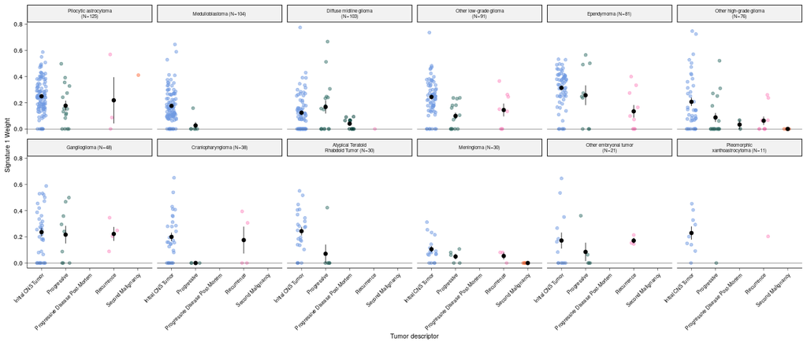

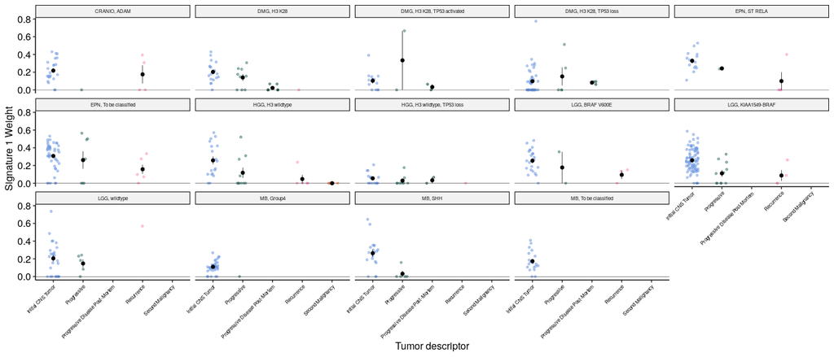

```r
# This chunk should NOT run in CI.
if (!(params$is_ci == 1)) {

  # Set seed for reproducibility
  set.seed(2022)

  # Grab the tumor descriptor colors
  tumor_colors <- tumor_df$hex_codes
  names(tumor_colors) <- tumor_df$color_names

  # First we can display proportions and tumor descriptor, across cancer display groups
  sig1_tumor_cancergroups <- sig1_exposures %>%
    ggplot2::ggplot() +
    ggplot2::aes(x = tumor_descriptor,
                 y = sig1_proportion,
                 color = tumor_descriptor) +
    ggplot2::geom_jitter(width = 0.2, alpha = 0.5, size = 1.5) +
    # light guiding line representing 0 exposure
    ggplot2::geom_hline(yintercept = 0, size = 0.15) +
    ggplot2::scale_color_manual(values = tumor_colors) +
    # add in mean +/- SE pointrange
    ggplot2::stat_summary(color = "black", size = 0.3) +
    ggplot2::facet_wrap(~cancer_group_display_n,nrow = 2) +
    ggplot2::labs(
      x = "Tumor descriptor",
      y = "Signature 1 Weight"
    ) +
    ggpubr::theme_pubr() +
    ggplot2::theme(
      axis.text.x = ggplot2::element_text(angle = 45, hjust = 1, size = 6.25),
      axis.text.y = ggplot2::element_text(size = 7.5),
      axis.title = ggplot2::element_text(size = 8),
      strip.text = ggplot2::element_text(size = 6),
      axis.line = ggplot2::element_line(size = ggplot2::rel(0.5)),
      axis.ticks = ggplot2::element_line(size = ggplot2::rel(0.5)),
      legend.position = "none"
    )

  # We can also viz with molecular subtypes, focusing only on subtypes with decent sample sizes. For now let's say N=15.
  subtypes <- sig1_exposures %>%
    dplyr::count(molecular_subtype) %>%
    dplyr::filter(n >= 15) %>%
    dplyr::pull(molecular_subtype)

  sig1_tumor_molsubs <- sig1_exposures %>%
    dplyr::filter(molecular_subtype %in% subtypes) %>%
    tidyr::drop_na(molecular_subtype) %>%
    ggplot2::ggplot() +
    ggplot2::aes(x = tumor_descriptor,
                 y = sig1_proportion,
                 color = tumor_descriptor) +
    ggplot2::geom_jitter(width = 0.2, alpha = 0.5, size = 1) +
    # light guiding line representing 0 exposure
    ggplot2::geom_hline(yintercept = 0, size = 0.15) +
    ggplot2::scale_color_manual(values = tumor_colors) +
    # add in mean guiding point
    ggplot2::stat_summary(color = "black", size = 0.25) +
    ggplot2::facet_wrap(~molecular_subtype,nrow = 3) +
    ggplot2::labs(
      x = "Tumor descriptor",
      y = "Signature 1 Weight"
    ) +
    ggpubr::theme_pubr() +
    ggplot2::theme(
      axis.text.x = ggplot2::element_text(angle = 45, hjust = 1, size = 6),
      strip.text = ggplot2::element_text(size = 6),
      legend.position = "none"
    )

  # Plot the plots
  print(sig1_tumor_cancergroups)
  print(sig1_tumor_molsubs)

  # Save the plots
  ggplot2::ggsave(signature1_tumor_cancergroups_file, sig1_tumor_cancergroups, width = 8, height = 4, useDingbats = FALSE)
  ggplot2::ggsave(signature1_tumor_molecularsubtypes_file, sig1_tumor_molsubs, width = 14, height = 6, useDingbats = FALSE)
}
```